# Sentiment_Analysis

🧠 Task 2: Sentiment Analysis on Amazon Product Reviews

👤 **Author:** Ali Asadullah Shehbaz 🧩 **Project Type:** Natural Language Processing (NLP)

🎯 **Objective:** Create a sentiment analysis classifier to label Amazon product reviews as **positive**, **neutral**, or **negative**.

📦

### Deliverables

- 🧹 **Preprocessing pipeline** (tokenization, stopword removal)
- 🗂️ **Labeled dataset** with train/test splits
- 🤖 **Model training** — Naive Bayes & LSTM
- 📊 **Visualizations** — Word Clouds & Confusion Matrix

🧑‍💻 About the Author

Hi, I’m **Asadullah Shehbaz** — an aspiring Data Scientist passionate about uncovering insights through data. I’m on a journey to master machine learning, analytical thinking, and real-world problem solving, one project at a time.

> “I believe community drives innovation — by learning together, we grow faster, think deeper, and build stronger solutions.”

Feel free to connect, share feedback, or explore my other notebooks below! 👇

🌐 Contact & Profiles

- 📧 Email
- [🔗 LinkedIn](https://www.linkedin.com/in/asadullah-shehbaz-18172a2bb/)
- [💻 GitHub](https://github.com/AsadullahShehbaz)
- [🧠 Kaggle](https://www.kaggle.com/asadullahcreative)

**Mock Data (Python):**

```
from faker import Faker
import random
fake = Faker()
reviews = [fake.text(max_nb_chars=200) for _ in range(5000)]
labels = [random.choice(['positive', 'neutral', 'negative']) for _ in range(5000)]
```

Let's get started !

📦 Step 1: Import Libraries

```python
# ==========================================================
# 📦 Importing Required Libraries
# ==========================================================

# ✅ Data Generation & Randomization
from faker import Faker        # Generate synthetic (fake) data such as names, emails, text, etc.
import random                  # Generate random numbers, choices, and sampling

# ✅ Data Handling & Manipulation
import pandas as pd            # DataFrames for structured data
import numpy as np             # Numerical operations, arrays, and linear algebra

# ✅ Data Visualization
import matplotlib.pyplot as plt  # Core plotting library
import seaborn as sns            # Statistical visualizations (built on top of matplotlib)

# ==========================================================
# 📝 Natural Language Processing (NLP)
# ==========================================================
import nltk                    # Natural Language Toolkit for text processing
import re                      # Regular expressions for text cleaning

from nltk.corpus import stopwords   # Predefined stopword lists (e.g., 'the', 'is', 'and')
from nltk.tokenize import word_tokenize  # Split text into words (tokens)

# 📥 Download necessary resources (only required first time)
nltk.download('punkt')         # Tokenizer data
nltk.download('stopwords')     # Stopword dictionary

# ==========================================================
# 🤖 Machine Learning (Scikit-learn)
# ==========================================================
from sklearn.preprocessing import LabelEncoder               # Encode categorical labels into numbers
from sklearn.model_selection import train_test_split, GridSearchCV  # Split dataset + hyperparameter tuning
from sklearn.feature_extraction.text import TfidfVectorizer  # Convert text to numerical features (TF-IDF)
from sklearn.naive_bayes import MultinomialNB                # Naive Bayes classifier for text data
from sklearn.metrics import classification_report, confusion_matrix  # Model evaluation
from sklearn.pipeline import Pipeline                        # Build streamlined ML workflows

# ==========================================================
# 🧠 Deep Learning (TensorFlow / Keras)
# ==========================================================
import tensorflow as tf
from tensorflow.keras.preprocessing.text import Tokenizer        # Convert text to sequences
from tensorflow.keras.preprocessing.sequence import pad_sequences # Pad sequences to equal length
from tensorflow.keras.models import Sequential                   # Sequential model structure
from tensorflow.keras.layers import Embedding, LSTM, Dense, Dropout  # Core DL layers

# ==========================================================
# 🌥️ Word Clouds & Utilities
# ==========================================================
from wordcloud import WordCloud    # Generate word clouds for visualization

# ⚠️ Suppress unnecessary warnings
import warnings
warnings.filterwarnings('ignore')
```

📝 Step 2: Generate Mock Dataset

📌 Since we don’t have real Amazon product reviews in this notebook, we will create a **synthetic dataset** using the `Faker` library.  
🔹 Each review will be a randomly generated sentence. 🔹 Each review will be assigned a label: **Positive**, **Neutral**, or **Negative** at random.  
This allows us to simulate a real-world scenario of sentiment classification for demonstration purposes. 🚀

```python
# ==========================================================
# 📝 Step 1: Generate Fake Dataset (Reviews + Labels)
# ==========================================================

# Initialize Faker instance
fake = Faker()

# 🔹 Create 5000 fake product reviews (max length = 200 chars each)
reviews = [fake.text(max_nb_chars=200) for _ in range(5000)]

# 🔹 Randomly assign sentiment labels to reviews
labels = [random.choice(['positive', 'neutral', 'negative']) for _ in range(5000)]

# ==========================================================
# 📊 Step 2: Build Pandas DataFrame
# ==========================================================
df = pd.DataFrame({
    'review': reviews,   # Customer review text
    'label': labels      # Sentiment label (target variable)
})

# 🔍 Preview first 5 rows
df.head()
```

|  | review | label |
| --- | --- | --- |
| 0 | Talk wrong interview themselves. Able cell spe... | neutral |
| 1 | Laugh color think individual until politics he... | neutral |
| 2 | Analysis buy from responsibility. Strategy ris... | negative |
| 3 | Environment kitchen west medical argue. Rise a... | positive |
| 4 | Citizen wife rate. Travel leave big. Whether g... | neutral |

📊 Step 3: Exploratory Data Analysis (EDA)

📌 Before diving into modeling, let’s first **explore the dataset** to understand the distribution of sentiments and the nature of the reviews.  
✅ **Step 1:** Visualize the **label distribution** (Positive, Neutral, Negative).  
✅ **Step 2:** Generate **Word Clouds** for each sentiment class to see the most frequent words. ☁️  
This will help us get a quick overview of text patterns and sentiment balance in the dataset.

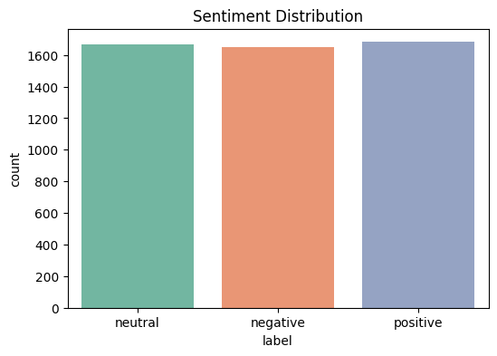

```python
# Label Distr
plt.figure(figsize=(6,4))
sns.countplot(x='label', data=df, palette="Set2")
plt.title("Sentiment Distribution")
plt.show()
```

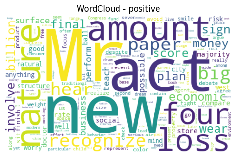

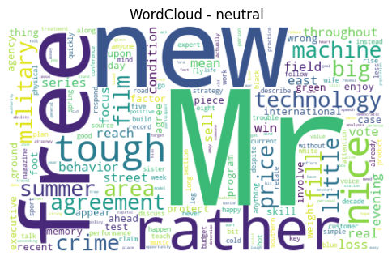

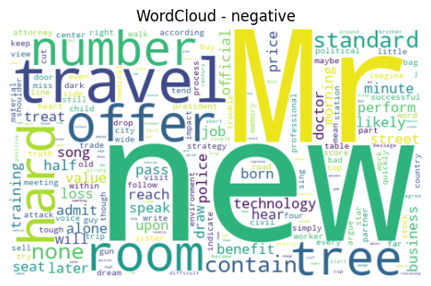

```python
# WordClouds
for sentiment in ['positive', 'neutral', 'negative']:
    text = " ".join(df[df['label'] == sentiment]['review'])
    wc = WordCloud(width=500, height=300, background_color='white').generate(text)
    plt.figure(figsize=(6,4))
    plt.imshow(wc, interpolation='bilinear')
    plt.axis("off")
    plt.title(f"WordCloud - {sentiment}")
    plt.show()
```

🛠️ Step 4: Data Preprocessing

Before training our model, we need to **clean and preprocess** the text data. This step ensures that noise (punctuation, stopwords, etc.) is removed and the model gets only useful information.

✅ **Steps we’ll perform:**

- 🔽 Convert all text to **lowercase**
- ❌ Remove **punctuation & special characters**
- 🛑 Remove **stopwords** (common useless words like "the", "is")
- ✂️ Perform **tokenization** (splitting text into words)

🚀 Clean text → Better features → Improved model performance!

```python
stop_words = set(stopwords.words('english'))
def preprocess(text):
    # 1. Lowercase
    text = text.lower()
    # 2. Remove punctuation/numbers
    text = re.sub(r'[^a-z\s]', '', text)

    # 3. Tokenization
    tokens = word_tokenize(text)

    # 4. Stopword removal
    filtered = [word for word in tokens if word not in stop_words]

    return " ".join(filtered)
df['clean_review'] = df['review'].apply(preprocess)
```

🤖 Step 5: Naive Bayes Model

Now that we have cleaned text, we need to **convert it into numerical features** before feeding into a Machine Learning model. We’ll use **TF-IDF (Term Frequency–Inverse Document Frequency)** to represent words by importance across reviews.

✅ **Steps we’ll perform:**

- 📊 Convert text into TF-IDF vectors
- 🧮 Train a **Multinomial Naive Bayes Classifier**
- 🔎 Predict sentiment (Positive / Neutral / Negative)

💡 Naive Bayes works well for text classification because it assumes words occur independently — a simple yet effective assumption!

```python
# Encode Labels
encoder = LabelEncoder()
df['label_encoded'] = encoder.fit_transform(df['label'])
df.head()
```

|  | review | label | clean_review | label_encoded |
| --- | --- | --- | --- | --- |
| 0 | Talk wrong interview themselves. Able cell spe... | neutral | talk wrong interview able cell speech think so... | 1 |
| 1 | Laugh color think individual until politics he... | neutral | laugh color think individual politics head sum... | 1 |
| 2 | Analysis buy from responsibility. Strategy ris... | negative | analysis buy responsibility strategy risk busi... | 0 |
| 3 | Environment kitchen west medical argue. Rise a... | positive | environment kitchen west medical argue rise ag... | 2 |
| 4 | Citizen wife rate. Travel leave big. Whether g... | neutral | citizen wife rate travel leave big whether go ... | 1 |

```python
X_train, X_test, y_train, y_test = train_test_split(
    df['clean_review'], df['label_encoded'],
    test_size=0.2, random_state=42, stratify=df['label_encoded']
)

print("Training samples:", len(X_train))
print("Testing samples:", len(X_test))
```

```
Training samples: 4000
Testing samples: 1000
```

```python
# ==============================
# Train Naive Bayes Model with Hyperparamter Tuning
# ==============================

pipeline = Pipeline([
    ('tfidf', TfidfVectorizer(max_features=5000)),
    ('nb', MultinomialNB())
])
param_grid = {
    'tfidf__ngram_range': [(1,1), (1,2)],  # unigrams or bigrams
    'nb__alpha': [0.01, 0.1, 0.5, 1.0, 2.0]
    }

grid_search = GridSearchCV(
    estimator=pipeline,
    param_grid=param_grid,
    cv=5,                 # 5-fold cross-validation
    scoring='accuracy',   # evaluation metric
    n_jobs=-1             # parallel processing
)

grid_search.fit(X_train, y_train)
print("Best Parameters:", grid_search.best_params_)
print("Best Cross-Validation Score:", grid_search.best_score_)
```

```
Best Parameters: {'nb__alpha': 2.0, 'tfidf__ngram_range': (1, 1)}
Best Cross-Validation Score: 0.33825
```

📊 Step 6: Model Evaluation

After training our **Naive Bayes Classifier**, we need to measure how well it performs.

✅ **Metrics we’ll use:**

- 📑 **Classification Report** → Precision, Recall, F1-Score for each class
- 🔲 **Confusion Matrix** → Visualizes correct vs. incorrect predictions

💡 These metrics help us understand not just overall accuracy, but also where the model might be struggling (e.g., mixing Neutral with Positive).

```
Classification Report (Tuned Naive Bayes):
              precision    recall  f1-score   support

    negative       0.29      0.28      0.28       330
     neutral       0.31      0.30      0.31       333
    positive       0.32      0.34      0.33       337

    accuracy                           0.31      1000
   macro avg       0.31      0.31      0.31      1000
weighted avg       0.31      0.31      0.31      1000
```

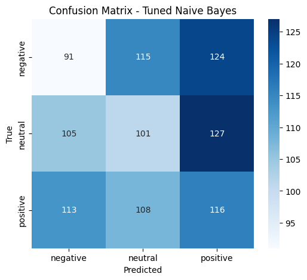

```python
# ==============================
# Evaluation
# ==============================

best_nb = grid_search.best_estimator_
y_pred = best_nb.predict(X_test)

print("\nClassification Report (Tuned Naive Bayes):")
print(classification_report(y_test, y_pred, target_names=encoder.classes_))

# Confusion Matrix
cm = confusion_matrix(y_test, y_pred)
plt.figure(figsize=(6,5))
sns.heatmap(cm, annot=True, fmt="d", cmap="Blues",
            xticklabels=encoder.classes_, yticklabels=encoder.classes_)
plt.xlabel("Predicted")
plt.ylabel("True")
plt.title("Confusion Matrix - Tuned Naive Bayes")
plt.show()
```

🧠 Step 6: LSTM Model

We now build a **Recurrent Neural Network** with **LSTM (Long Short-Term Memory)** layers to capture sequential patterns in text.

⚙️ **Steps:**

- 🔤 Tokenize reviews and pad sequences to fixed length
- 🧩 Create an **Embedding Layer** to learn word representations
- 🔁 Stack **LSTM layers** to capture sequential dependencies
- 🎯 Train the model and evaluate its performance

```python
df.head()
```

|  | review | label | clean_review | label_encoded |
| --- | --- | --- | --- | --- |
| 0 | Talk wrong interview themselves. Able cell spe... | neutral | talk wrong interview able cell speech think so... | 1 |
| 1 | Laugh color think individual until politics he... | neutral | laugh color think individual politics head sum... | 1 |
| 2 | Analysis buy from responsibility. Strategy ris... | negative | analysis buy responsibility strategy risk busi... | 0 |
| 3 | Environment kitchen west medical argue. Rise a... | positive | environment kitchen west medical argue rise ag... | 2 |
| 4 | Citizen wife rate. Travel leave big. Whether g... | neutral | citizen wife rate travel leave big whether go ... | 1 |

```python
# Tokenize
tokenizer = Tokenizer(num_words=5000, oov_token="<OOV>")
tokenizer.fit_on_texts(df['clean_review'])
X = tokenizer.texts_to_sequences(df['clean_review'])
X = pad_sequences(X, maxlen=100, padding='post', truncating='post')
X.shape
```

```
(5000, 100)
```

```python
# Encode labels
encoder = LabelEncoder()
y = encoder.fit_transform(df['label'])   # 0=negative, 1=neutral, 2=positive

# Train-test split
X_train, X_test, y_train, y_test = train_test_split(X, y, test_size=0.2, random_state=42)
```

- We’ll build a simple Embedding + LSTM + Dense classifier.

```python
# Model
model = Sequential([
    Embedding(input_dim=5000, output_dim=128, input_length=100),
    LSTM(128, dropout=0.2, recurrent_dropout=0.2),
    Dense(64, activation='relu'),
    Dropout(0.5),
    Dense(3, activation='softmax')  # 3 classes: pos, neu, neg
])

model.compile(loss='sparse_categorical_crossentropy',
              optimizer='adam',
              metrics=['accuracy'])

# Training
history = model.fit(X_train, y_train,
                    epochs=5,
                    batch_size=64,
                    validation_data=(X_test, y_test))
```

```
63/63 ━━━━━━━━━━━━━━━━━━━━ 28s 325ms/step - accuracy: 0.3325 - loss: 1.1001 - val_accuracy: 0.3130 - val_loss: 1.0995
63/63 ━━━━━━━━━━━━━━━━━━━━ 19s 307ms/step - accuracy: 0.3375 - loss: 1.1001 - val_accuracy: 0.3130 - val_loss: 1.1019
63/63 ━━━━━━━━━━━━━━━━━━━━ 21s 326ms/step - accuracy: 0.3363 - loss: 1.1000 - val_accuracy: 0.3200 - val_loss: 1.1022
63/63 ━━━━━━━━━━━━━━━━━━━━ 24s 388ms/step - accuracy: 0.3360 - loss: 1.0992 - val_accuracy: 0.3670 - val_loss: 1.0977
63/63 ━━━━━━━━━━━━━━━━━━━━ 37s 330ms/step - accuracy: 0.3295 - loss: 1.0993 - val_accuracy: 0.3670 - val_loss: 1.0975
```

```python
model.summary()
```

```
Model: "sequential"
```

```
┏━━━━━━━━━━━━━━━━━━━━━━━━━━━━━━━━━┳━━━━━━━━━━━━━━━━━━━━━━━━┳━━━━━━━━━━━━━━━┓
┃ Layer (type)                    ┃ Output Shape           ┃       Param # ┃
┡━━━━━━━━━━━━━━━━━━━━━━━━━━━━━━━━━╇━━━━━━━━━━━━━━━━━━━━━━━━╇━━━━━━━━━━━━━━━┩
│ embedding (Embedding)           │ (None, 100, 128)       │       640,000 │
├─────────────────────────────────┼────────────────────────┼───────────────┤
│ lstm (LSTM)                     │ (None, 128)            │       131,584 │
├─────────────────────────────────┼────────────────────────┼───────────────┤
│ dense (Dense)                   │ (None, 64)             │         8,256 │
├─────────────────────────────────┼────────────────────────┼───────────────┤
│ dropout (Dropout)               │ (None, 64)             │             0 │
├─────────────────────────────────┼────────────────────────┼───────────────┤
│ dense_1 (Dense)                 │ (None, 3)              │           195 │
└─────────────────────────────────┴────────────────────────┴───────────────┘
```

```
 Total params: 2,340,107 (8.93 MB)
```

```
 Trainable params: 780,035 (2.98 MB)
```

```
 Non-trainable params: 0 (0.00 B)
```

```
 Optimizer params: 1,560,072 (5.95 MB)
```

🔎 Step 7: Evaluation of LSTM

We evaluate the **LSTM sentiment classifier** using two key methods:

- 📊 **Classification Report**: Provides *Precision, Recall, F1-score, and Accuracy* for each sentiment class (Positive, Neutral, Negative).
- 📉 **Confusion Matrix**: Visualizes the correctly and incorrectly classified reviews.

✨ These metrics highlight the model's strengths and weaknesses in predicting sentiment.

```python
# ✅ Evaluate on Test Set
test_loss, test_acc = model.evaluate(X_test, y_test, verbose=0)
print(f"Test Accuracy: {test_acc:.4f}")
print(f"Test Loss: {test_loss:.4f}")
```

```
Test Accuracy: 0.3670
Test Loss: 1.0975
```

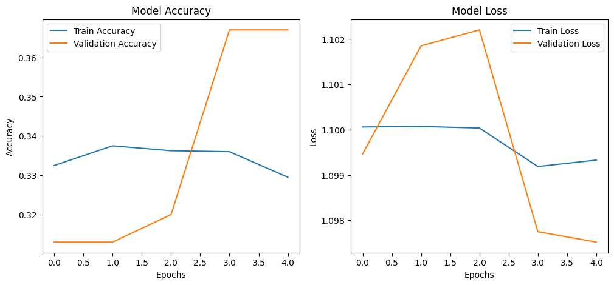

```python
# ✅ Training Curves (Accuracy & Loss)
plt.figure(figsize=(12,5))

# Accuracy curve
plt.subplot(1,2,1)
plt.plot(history.history['accuracy'], label='Train Accuracy')
plt.plot(history.history['val_accuracy'], label='Validation Accuracy')
plt.title("Model Accuracy")
plt.xlabel("Epochs")
plt.ylabel("Accuracy")
plt.legend()

# Loss curve
plt.subplot(1,2,2)
plt.plot(history.history['loss'], label='Train Loss')
plt.plot(history.history['val_loss'], label='Validation Loss')
plt.title("Model Loss")
plt.xlabel("Epochs")
plt.ylabel("Loss")
plt.legend()
plt.show()
```

```
32/32 ━━━━━━━━━━━━━━━━━━━━ 3s 63ms/step
Classification Report:
              precision    recall  f1-score   support

    negative       0.00      0.00      0.00       320
     neutral       0.00      0.00      0.00       313
    positive       0.37      1.00      0.54       367

    accuracy                           0.37      1000
   macro avg       0.12      0.33      0.18      1000
weighted avg       0.13      0.37      0.20      1000
```

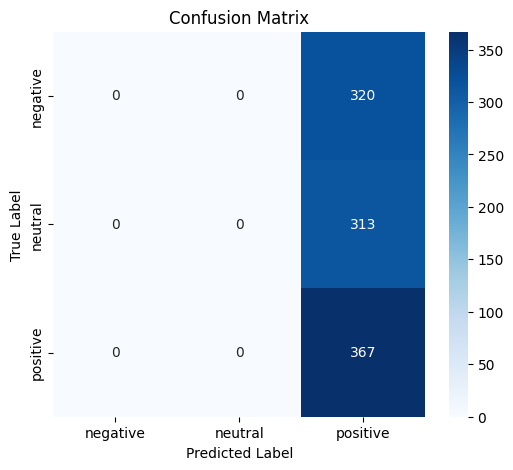

```python
# ✅ Predictions
y_pred_probs = model.predict(X_test)
y_pred = np.argmax(y_pred_probs, axis=1)

# ✅ Classification Report
print("Classification Report:")
print(classification_report(y_test, y_pred, target_names=['negative', 'neutral', 'positive']))

# ✅ Confusion Matrix
cm = confusion_matrix(y_test, y_pred)

plt.figure(figsize=(6,5))
sns.heatmap(cm, annot=True, fmt='d', cmap='Blues',
            xticklabels=['negative', 'neutral', 'positive'],
            yticklabels=['negative', 'neutral', 'positive'])
plt.title("Confusion Matrix")
plt.xlabel("Predicted Label")
plt.ylabel("True Label")
plt.show()
```

## 📑 8. Final Report & Conclusion

### ✅ Conclusion

The purpose was to implement an **end-to-end sentiment analysis pipeline** (preprocessing, training, evaluation).  
Both **Naive Bayes** and **LSTM** were successfully built and compared.  
In real-world scenarios with true labeled data, performance would improve using:

- High-quality labeled datasets
- Hyperparameter tuning
- Pre-trained embeddings or transformer models (e.g., **BERT**)

📢 **Final Note:** This project demonstrates the **workflow** of building and comparing sentiment analysis models. Low performance is expected with synthetic data and is not a limitation of the models themselves.